# Integration test for MRSea 2d salsa with other variables, with 1d smooth, no panels, no interactions

LAS Scott-Hayward, C Fell

2020-08-10

2020-08-09

2020-08-10

## Introduction

This is the sixth in a series of tests that can be used to check changes to the MRSea package do not break previously working elements. They replicate the case study in the vignette but broken down into chunks. This sixth one checks the 2D salsa functions with other variables, with a 1d smooth, no panels and no interactions.

```r
count.data <- read.csv("1.count.data.csv")
data <- count.data
data$response <- round(data$NHAT)
data$blockid <- paste(data$transect.id, data$season, data$impact,sep = "")
attach(data)
```

## Set up

Set a prediction grid.

Set up the initial model with factor covariates and offset term

```r
initialModel <- glm(response ~ 1 + offset(log(area)),
  family = "quasipoisson", data = data)
```

```r
salsa1dlist <- list(
  fitnessMeasure = "cv.gamMRSea",
  minKnots_1d = 2,
  maxKnots_1d = 5,
  startKnots_1d = 1,
  degree = 2,
  maxIterations = 10,
  gaps = c(0),
  cv.opts=list(cv.gamMRSea.seed=1, K=5)
)
```

```r
# run SALSA
set.seed(1234)
salsa1dOutput <- runSALSA1D(initialModel, salsa1dlist, c("depth"), predictionData=predictData, datain=data,removal=TRUE)
```

Number of knots selected for depth: 1 this should be 1.

Location of knot selected for depth: -11.3975 this should be -12.212.

## Selection of flexibility for 2D smooth term

Create a grid of knots that will be used as possible knot locations.

```r
knotgrid <- read.csv("4.knotgrid.csv")
```

Sum of knotgrid: 2018630 this should be 2018630.

Sum of datadist: 8224.849 this should be 8224.849.

Sum of knotdist: 1775357 this should be 1775357.

Set salsa 2d parameters

```r
# make parameter set for running salsa2d
salsa2dlist<-list(
  fitnessMeasure = 'cv.gamMRSea',
  knotgrid = knotgrid,
  startKnots=5,
  minKnots=4,
  maxKnots=12,
  gap=0,
  cv.opts=list(cv.gamMRSea.seed=1, K=10)
)
```

## Predictions compared to original

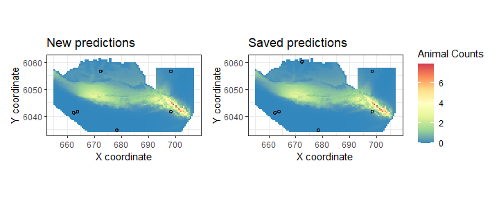

```
[1] "warning: no offset included as link response specified"
```

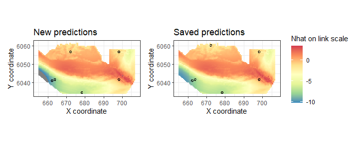

Sum of all predictions on response scale: 2190.575 this should be 17472.

Sum of all predictions on link scale: -7544.685 this should be -65738.33.

Time for training: 7 Original time: 9.0.

Number of model fits: 199 Original model fits: 227

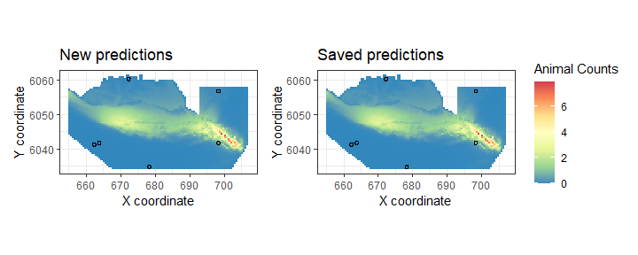

```
[1] "warning: no offset included as link response specified"
```

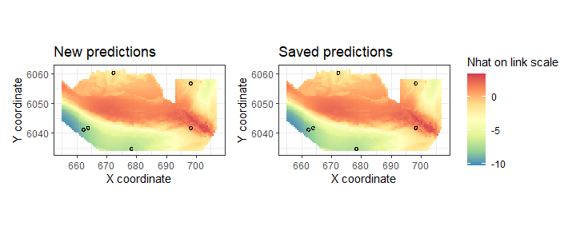

Sum of all predictions on response scale: 2192.313 this should be 2192.313.

Sum of all predictions on link scale: -7589.302 this should be -7589.302.

Time for training: 6.155796 Original time: 8.3.

Number of model fits: 227 Original model fits: 227

coefficients of new model

[output not shown]

coefficients of saved model

| Estimate | Std..Error | Robust.S.E. | t.value | Pr…t.. |
| --- | --- | --- | --- | --- |
| -4.969 | 7.102 | 7.102 | -0.700 | 0.484 |
| 0.972 | 7.638 | 7.638 | 0.127 | 0.899 |
| 10.669 | 6.895 | 6.895 | 1.547 | 0.122 |
| 7.396 | 7.195 | 7.195 | 1.028 | 0.304 |
| -4.057 | 0.858 | 0.858 | -4.731 | 0.000 |
| -5.473 | 1.602 | 1.602 | -3.416 | 0.001 |
| -45.735 | 10.571 | 10.571 | -4.326 | 0.000 |
| 2.062 | 0.865 | 0.865 | 2.382 | 0.017 |
| -5.312 | 1.470 | 1.470 | -3.614 | 0.000 |
| 44.184 | 9.792 | 9.792 | 4.512 | 0.000 |

Sum of all estimates: 4.614173 this should be -1.929935.

Sum of all robust SE: 79.71061 this should be 55.14092.

Standard errors are equal to robust standard errors: TRUE

Dispersion: 65.96385 this should be 35.85788.

Mean square error to truth: 0.416686 this should be 0.4298723.

residual sum square error to data: 11.5544 this should be 11.44848.

Mean square error to truth seen: 0.4376325 this should be 0.4298723.

Mean square error to truth unseen: 0.4099471 this should be 0.4298723.

Sum of all estimates: -0.2626807 this should be -0.2626807.

Sum of all robust SE: 53.9878 this should be 53.9878.

Standard errors are equal to robust standard errors: TRUE

Dispersion: 30.48591 this should be 30.48591.

Mean square error to truth: 0.4155882 this should be 0.4155882.

residual sum square error to data: 5.925519 this should be 5.925519.

Mean square error to truth seen: 0.441726 this should be 0.441726.

Mean square error to truth unseen: 0.4071793 this should be 0.4071793.